# STAT390: Homework 1

Ken

2023-10-01

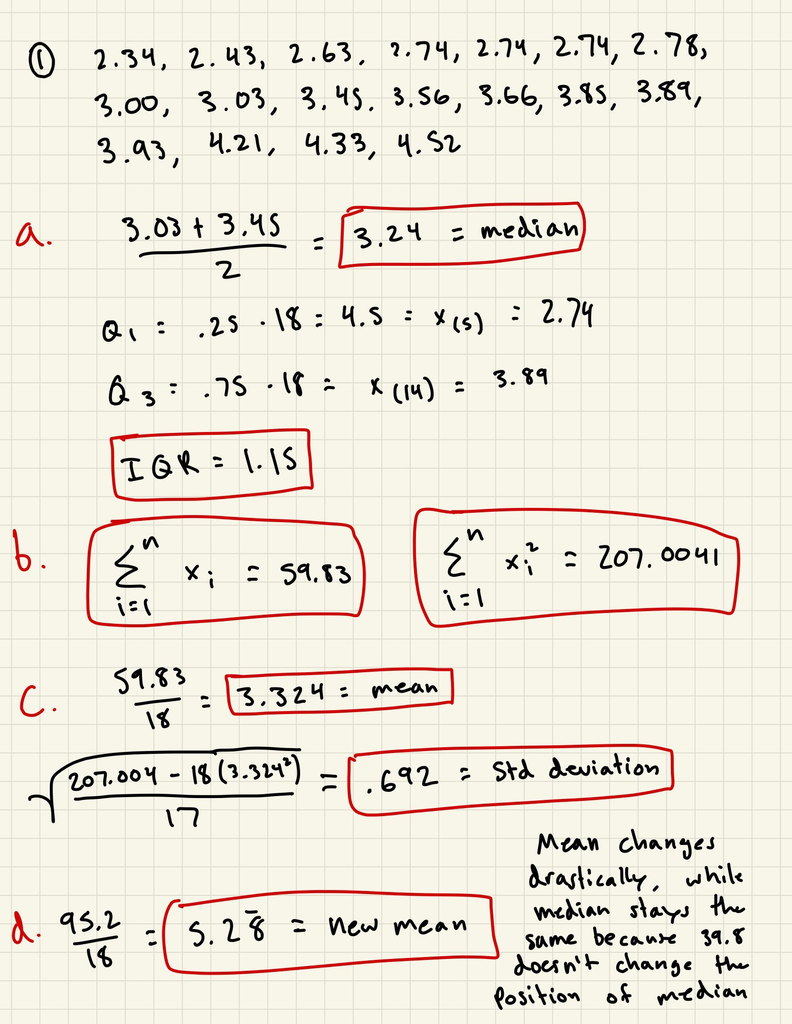

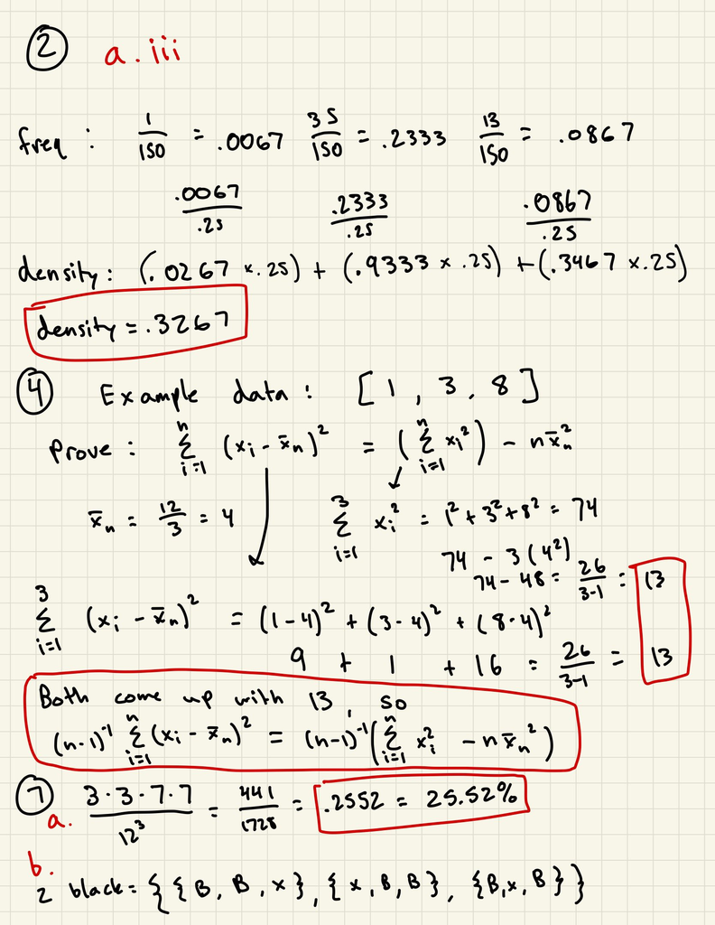

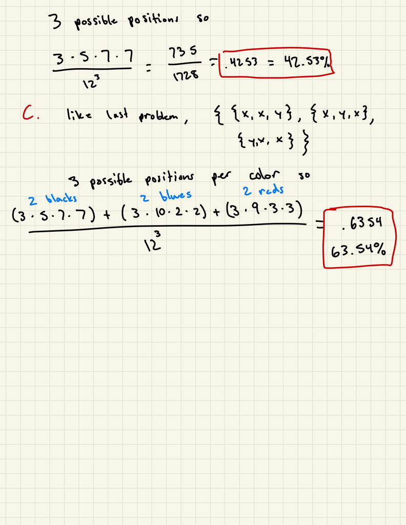

# Question Two

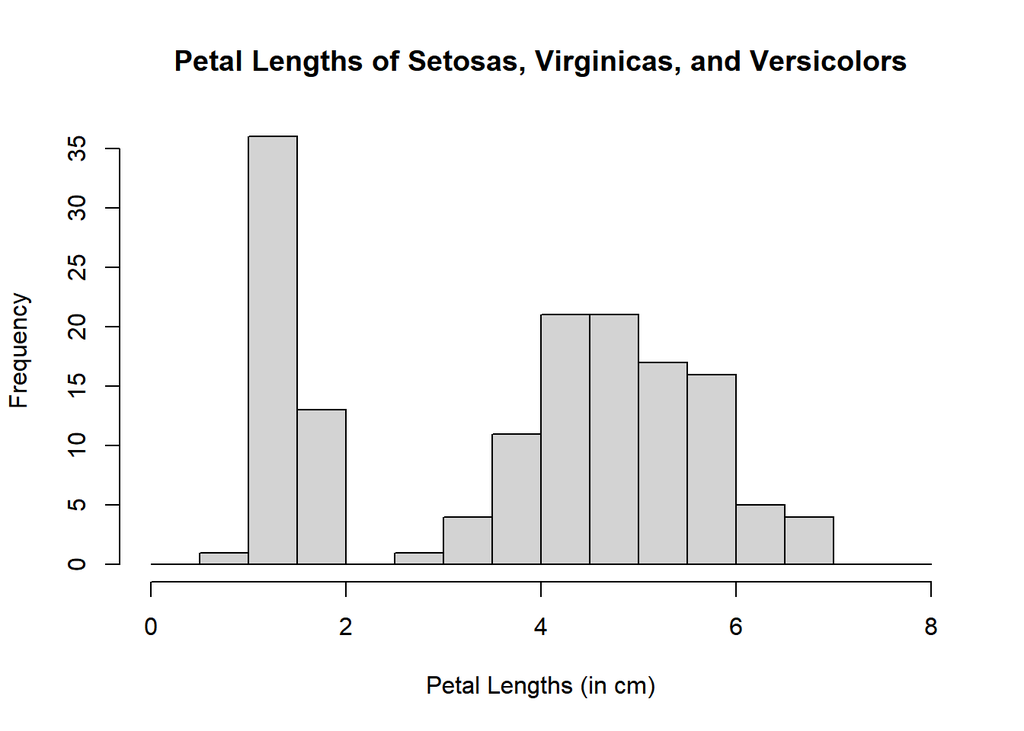

```r
iris <- read.csv("iris.csv", header=TRUE)
histogram <- hist(iris$Petal.Length,
                  breaks=seq(0,8,l=17),
                  main="Petal Lengths of Setosas, Virginicas, and Versicolors",
                  xlab="Petal Lengths (in cm)",
                  ylab="Frequency")
```

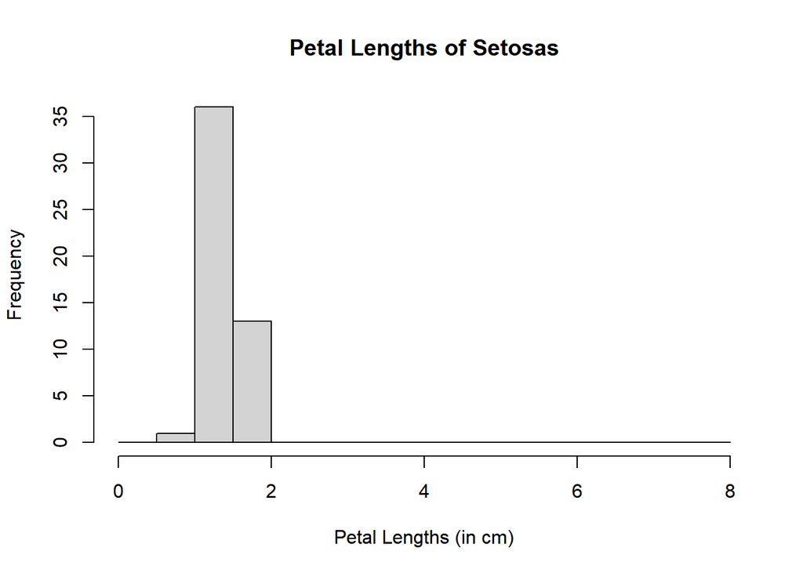

```r
setosas <- iris %>% filter(iris$Species == "setosa")
setosa_hist <- hist(setosas$Petal.Length,
                  breaks=seq(0,8,l=17),
                  main="Petal Lengths of Setosas",
                  xlab="Petal Lengths (in cm)",
                  ylab="Frequency")
```

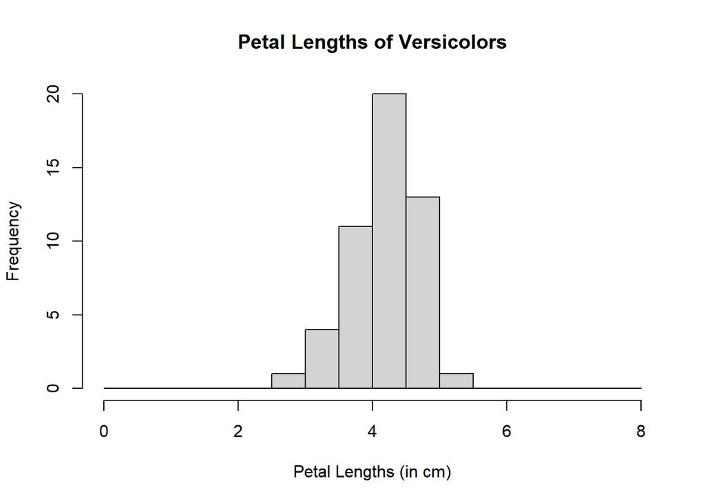

```r
versicolors <- iris %>% filter(iris$Species == "versicolor")
versicolor_hist <- hist(versicolors$Petal.Length,
                  breaks=seq(0,8,l=17),
                  main="Petal Lengths of Versicolors",
                  xlab="Petal Lengths (in cm)",
                  ylab="Frequency")
```

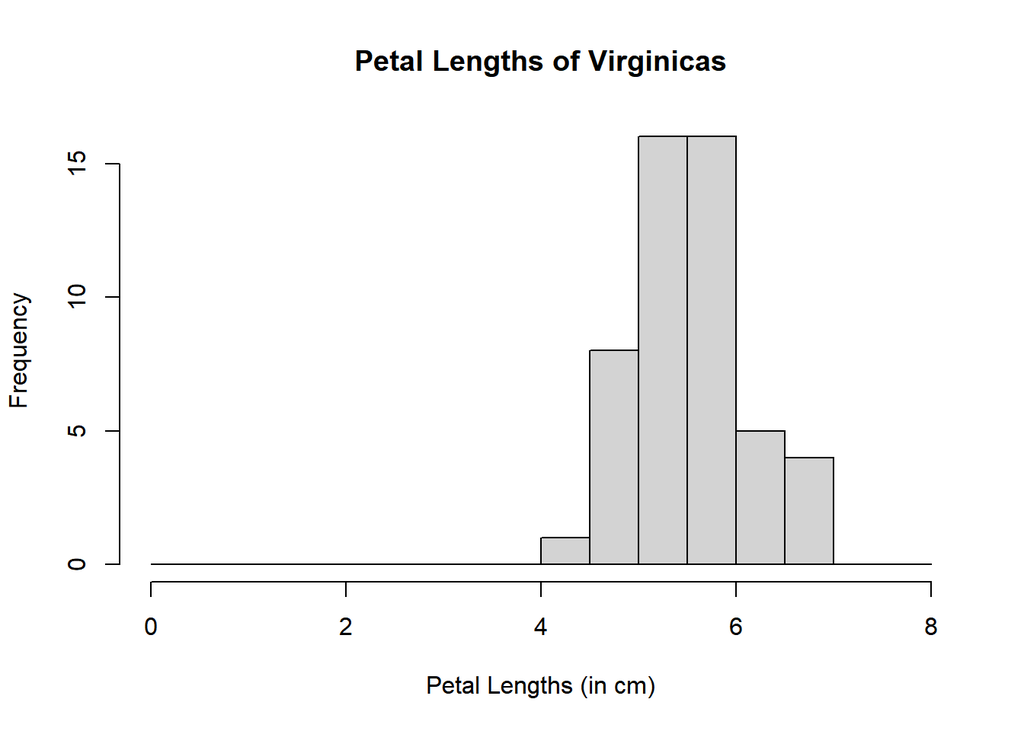

```r
virginicas <- iris %>% filter(iris$Species == "virginica")
virginica_hist <- hist(virginicas$Petal.Length,
                  breaks=seq(0,8,l=17),
                  main="Petal Lengths of Virginicas",
                  xlab="Petal Lengths (in cm)",
                  ylab="Frequency")
```

The most striking difference between the three is that each are in a different segment of the histogram. For example, the setosa petal lengths are on the lower end, versicolor petal lengths are in the middle, and virginica petal lengths are on the higher end.

Based on the histogram, the setosas have the least variability in petal length because the setosas are not as widely spread out across multiple bins like versicolors and viriginicas are. As shown below, the setosas do indeed have the least variability.

```r
var(setosas$Petal.Length)
```

```
## [1] 0.03015918
```

```r
var(versicolors$Petal.Length)
```

```
## [1] 0.2208163
```

```r
var(virginicas$Petal.Length)
```

```
## [1] 0.3045878
```

# Question 3

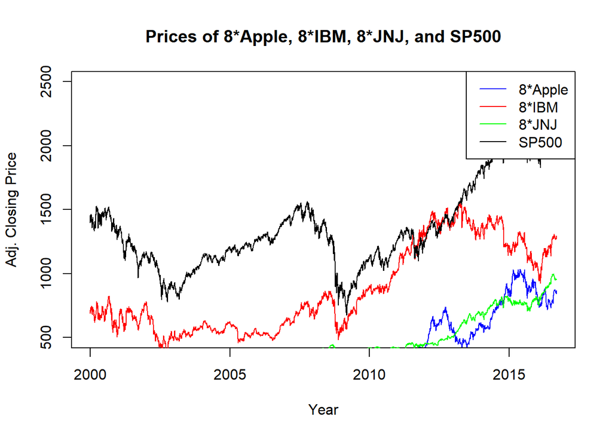

```r
apple <- read.csv("APPL.csv", header=TRUE)
ibm <- read.csv("IBM.csv", header=TRUE)
jnj <- read.csv("JNJ.csv", header=TRUE)
sp500 <- read.csv("SP500.csv", header=TRUE)

dates <- apple[,1]
dates <- strptime(dates, "%Y-%m-%d")
dates <- rev(dates)

pApple <- apple[,7]
pApple <- rev(pApple)
pIBM <- ibm[,7]
pIBM <- rev(pIBM)
pJNJ <- jnj[,7]
pJNJ <- rev(pJNJ)
pSP500 <- sp500[,7]
pSP500 <- rev(pSP500)

plot(dates, 8*pApple, ylim = c(500, 2500), col="blue", type="l", xlab = "Year", ylab = "Adj. Closing Price")
lines(dates, 8*pIBM, col="red")
lines(dates, 8*pJNJ, col="green")
lines(dates, pSP500, col="black")

title("Prices of 8*Apple, 8*IBM, 8*JNJ, and SP500")
legend(x="topright", legend=c("8*Apple", "8*IBM", "8*JNJ", "SP500"), lty=c(1, 1), col = c("blue", "red", "green", "black"), lwd = 1)
```

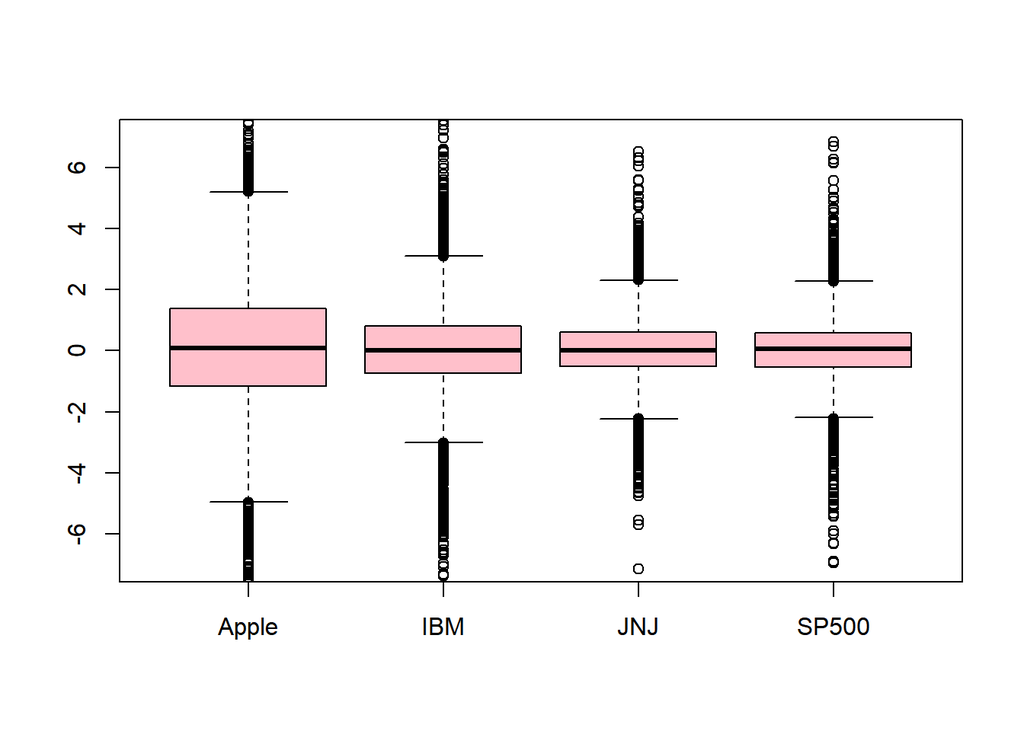

```r
logApple <- diff(log(pApple))*100
logIBM <- diff(log(pIBM))*100
logJNJ <- diff(log(pJNJ))*100
logSP500 <- diff(log(pSP500))*100

bp <- boxplot(list(logApple, logIBM, logJNJ, logSP500), names = c("Apple", "IBM", "JNJ", "SP500"), ylim=c(-7,7), col = "pink", xlab="")
```

```r
summary(logApple)
```

```
##      Min.   1st Qu.    Median      Mean   3rd Qu.      Max.
## -73.12469  -1.15228   0.07750   0.08009   1.38442  13.01943
```

```r
summary(logIBM)
```

```
##      Min.   1st Qu.    Median      Mean   3rd Qu.      Max.
## -16.89162  -0.73623   0.01864   0.01376   0.79594  11.35364
```

```r
summary(logJNJ)
```

```
##      Min.   1st Qu.    Median      Mean   3rd Qu.      Max.
## -17.25166  -0.52485   0.01784   0.03274   0.61147  11.53729
```

```r
summary(logSP500)
```

```
##      Min.   1st Qu.    Median      Mean   3rd Qu.      Max.
## -9.469512 -0.536993  0.052386  0.009644  0.588574 10.957197
```

```r
IQR(logApple)
```

```
## [1] 2.536701
```

```r
sd(logApple)
```

```
## [1] 2.81097
```

```r
IQR(logIBM)
```

```
## [1] 1.532177
```

```r
sd(logIBM)
```

```
## [1] 1.670554
```

```r
IQR(logJNJ)
```

```
## [1] 1.13632
```

```r
sd(logJNJ)
```

```
## [1] 1.222967
```

```r
IQR(logSP500)
```

```
## [1] 1.125568
```

```r
sd(logSP500)
```

```
## [1] 1.253355
```

Ranked from highest risk to lowest: Apple, IBM, SP500, JNJ.

# Question 5

The first statement is more probable because the second statement is a subset of the first, which means P(second statement) <= P(first statement). Also, from a non-statistics standpoint, LaGrange, Georgia is a lot more specific than North America, covering a lot less area, and Georgia is also not a tornado hotspot compared to other places in North America.

# Question 6

### a.

Sample space of flipping a coin three times: {HHH, HHT, HTT, HTH, THH, THT, TTT, TTH}

### b.

1. A = {HTT, TTH, THT}
2. B = {TTT, TTH, HTT, THT}
3. C = {HTT, HTH, HHT, HHH}

### c.

P(A) = 3/8, P(B) = 1/2, P(C) = 1/2